# Problem 1

### Part A: Setting Up Your Workspace

```python
#
import os
os.getcwd()
```

```
'/Users/yukening/Documents/CompFin/hw1'
```

The code `os.getcwd()` is used to get the path of the current working directory. The `os` module is a standard Python library that provides functions to interact with the operating system, and `getcwd()` specifically returns the current directory where this Jupyter Notebook is running. This output helps us confirm the file path and organize project files more effectively.

### Part B: Importing Data

```python
import pandas as pd
inflation = pd.read_csv('CPIAUCSL.csv')
inflation.head()
```

|  | DATE | CPIAUCSL_PC1 |
| --- | --- | --- |
| 0 | 1948-01-01 | 10.24209 |
| 1 | 1948-02-01 | 9.48196 |
| 2 | 1948-03-01 | 6.81818 |
| 3 | 1948-04-01 | 8.27273 |
| 4 | 1948-05-01 | 9.38497 |

The dataset includes two columns:

- **DATE**: This column represents the date in "YYYY-MM-DD" format, showing each month's data.
- **CPIAUCSL_PC1**: This column represents the annual percent change in the Consumer Price Index (CPI), which is a measure of inflation.

Each row corresponds to a specific month, showing the inflation rate at that time.

### Part C: Plotting Data

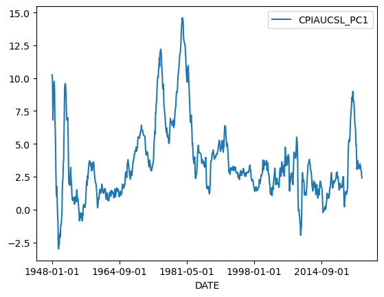

```python
inflation.plot(x='DATE', y='CPIAUCSL_PC1')
```

#### With label

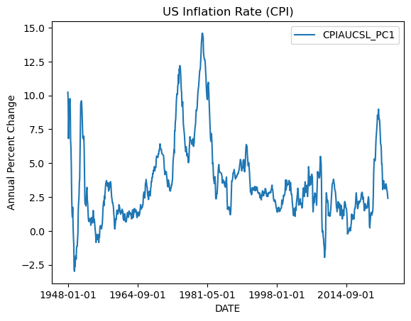

```python
inflation.plot(x='DATE', y='CPIAUCSL_PC1', ylabel='Annual Percent Change', legend=True, title='US Inflation Rate (CPI)')
```

[figure not shown]

##### Summary

While the Jupyter Notebook plot provides a clear visualization of CPI trends over time, the FRED plot is more visually comprehensive and includes additional contextual information. The FRED plot may appear more polished and informative for general audiences, while the Jupyter Notebook plot is sufficient for quick data exploration.